# B2 Rebound Analysis Update

Fan Bu

07/07/2020

## Overview

Main updates

- Added more “animal information”: Sex, challenge numbers, dosage
- Adjusted for FDR (using q-values) of the univariate Cox PH models
- Re-ran Cox PH “Lasso” model with manually selected predictors (took out the ones with high correlation to avoid colinearity)
- Literature review (on statistical inference of dynamical models)

## Investigating more predictors

The updated list of potential predictors:

- **Animal characteristics**: Sex, A01, challenge number, dosage
- **Viral load pre ART**: peak viral load, viral load at treatment & area-under-VL-curve
- **Antibody response**:
  - ELISA: GP41 and GP120, peak level and level at treatment
  - Neutralization: Point IC50 & Pos AUC measured at 0, 2, 4, 8 weeks post ATI
- **Cell-associated RNA and DNA**:
  - SHIV RNA copies per million cell RNA: measured in blood, lymph node and rectal biopsy at 8 and 56 weeks post infection (RB only at 56 weeks)
  - SHIV DNA copies per million cell DNA: measured in blood, lymph node and rectal biopsy at 8, 16, 36 and 56 weeks post infection (no RB at 8 weeks)
- **Absolute CD4 and CD8 cell counts**:
  - Estimated using flow cytometry and CBC data
  - “Measurements” at 0, 4, 8 weeks

## On animal characteristics

- Sex and A01 (both are factor variables): no significant effect on time to rebound
- Challenge number and dosage: not very high concordance with order to rebound
  - challeng number: $C = 0.625$ (ranked #11)
  - dosage: $C=0.579$ (ranked #15)

Below is the KM curve stratified by Sex. The univariate Cox PH model fitted with `Sex` as the predictor doesn’t suggest any significant effect either ($p=0.4$ by LRT).

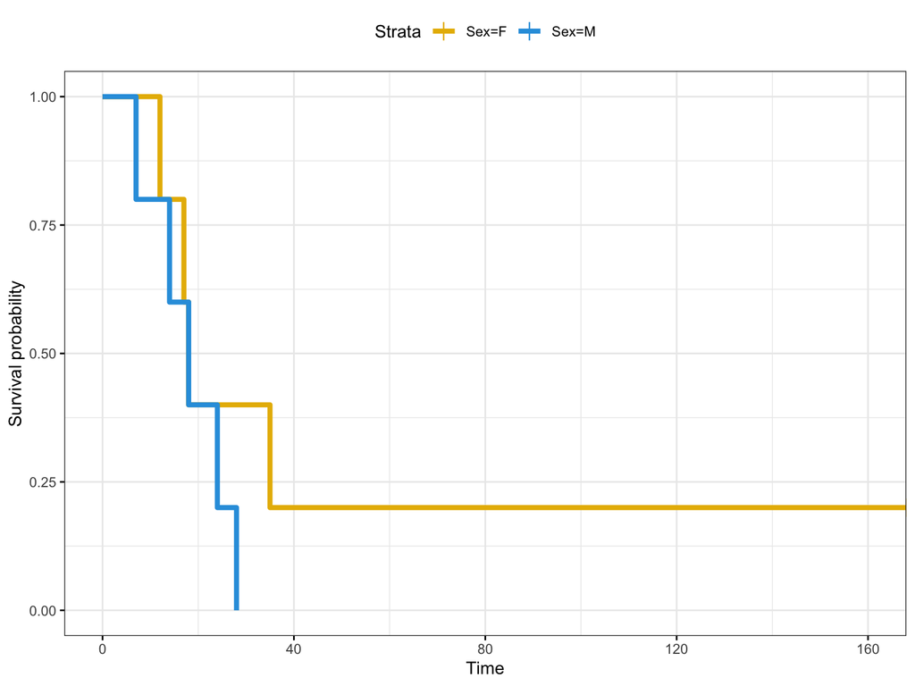

## Adjust for FDR (univariate models)

A univriate model is fitted for each of the potential predictors (updated), and for each model, the **q-value** (or “FDR”, proposed by Benjamini & Hochberg (1995)) is computed based on the p-value of likelihood-ratio-test for significance.

The only predictor with a FDR $<0.2$ is `pos_auc_0_weeks_post_ATI`, with a q-value of $0.09284$.

## “CoxNet” with pre-selected predictors

A “candidate pool” of potential predictors is manually selected after examining the pairwise correlation between all predictors in the dataset.

(The general selection criterion is to drop one of two variables if the correlation is $>0.8$ - this is not carried out very strictly as the goal is simply to avoid too much collinearity).

After the manual selection, the number of numerical predictors is reduced from $39$ to $23$.

A “best model” is obtained via 5-fold cross validation (again, the outcome isn’t very stable).

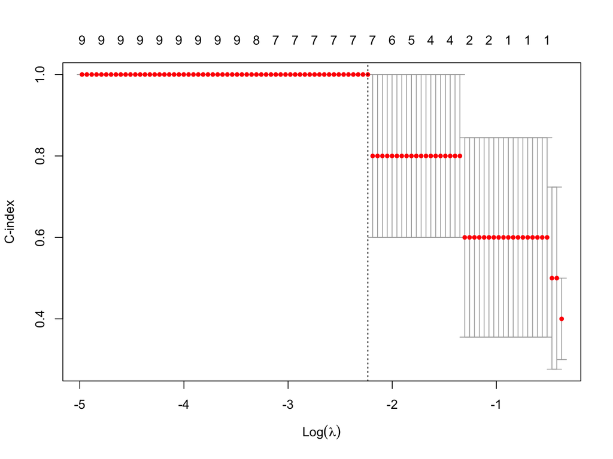

| Predictor | Coefficient |
| --- | --- |
| log_peak_gp41 | -2.1284 |
| log_DNA_copies_Blood_16 | -0.0858 |
| log_DNA_copies_RB_56 | 0.3923 |
| pos_auc_0_weeks_post_ATI | -14.3837 |
| log_Abs_CD4_week8 | -3.2844 |
| Challenge_times | -1.3414 |
| Dosage | -0.0013 |

## “CoxNet” with pre-selected predictors (Cont’d)

Same as last time, we can also get a “predictor inclusion ranking table” from the model outcomes.

Here in row $n$, we also provide the multivariate concordance using predictors $1,2,\ldots,n$. Understandably, concordance can reach 1 (or very close to 1) when we add more and more predictors, but this is not desired as a super good fit to the data often leads to overfitting; we may want to stop at 4 or even less predictors to be safe.

| Inclusion_Rank | Predictor | Coefficient | Rebound_Effect | Cum_concordance | LOOCV_deviance |
| --- | --- | --- | --- | --- | --- |
| 1 | pos_auc_0_weeks_post_ATI | - | delay | 0.7955 | 4.0113 |
| 2 | log_peak_gp41 | - | delay | 0.8636 | 3.6217 |
| 3 | log_Abs_CD4_week8 | - | delay | 0.9318 | 3.7286 |
| 4 | Challenge_times | - | delay | 0.9545 | 3.7703 |
| 5 | log_DNA_copies_RB_56 | + | accelerate | 1.0000 | 3.8759 |
| 6 | Dosage | - | delay | 1.0000 | 3.8821 |
| 7 | log_DNA_copies_Blood_16 | - | delay | 1.0000 | 3.9334 |
| 8 | log_RNA_copies_blood_56 | - | delay | 1.0000 | 5.1808 |
| 9 | log_peak_vl_2 | + | accelerate | 1.0000 | 5.4112 |

## On literature review

The general framework of parameter estimation for ODE-based models:

$$\begin{align}
x'(t) &= f(t, x(t), \theta),\\
x(0) &= x_0,\\
y(t) &= h(x(t), x_0, \theta) + \epsilon(t).
\end{align}$$
Here $x(t)$ is the “mechanistic” model and $y(t)$ is the observed data. The goal is to estimate $\theta$.

Main approaches:

- Work with $\epsilon(t)$ to elicit a “likelihood”, and then do MLE
  - oftentimes it’s reduced to nonlinear LS
  - but can be more complicated if, say, the model is hierarchical (e.g., mixed effects model)
- “Smooth” $y(t)$ to get an estimate of $x(t)$ and then work with $x'(t)$ directly
  - “nonparametric” (using splines) so somewhat more flexible
  - minimizing $\lVert \hat{x}'(t) - x'(t) \rVert_2$ can be easier and doesn’t require knowing the initial conditions accurately

## Estimation framework based on linear noise approximation and generalized least squares

Start with a continuous-time Markov Chain formulation, and for simplicity, only work with a 1-d process (multi-dim case is very similar).

Suppose that, for process $y(t)$, $a(y(t))$ is the instantaneous rate; i.e.,

$$a(y(t)) \Delta t = \text{prob. of an event in infinitesimal interval } [t, t+\Delta t).$$

Now we discretize the process by considering the process value at a time step $\tau$. Assume that $\tau$ satisfies the following two conditions:

1. $a(y(t))$ is approximately constant on $[t,t+\tau)$,
2. $a(y(t))\tau >> 1$.

(Note that these two conditions are easy to satisfy in a system very close to the thermodynamic limit, but can be hard to satisfy in a small-size population.)

**Condition 1** means that the event count on interval $[t,t+\tau)$, $\Delta y(t,\tau)$, can be approximated by a Poisson random variable with rate $a(y(t))\tau$.

**Condition 2** suggests that $E(\Delta y(t,\tau))$ is large enough that $\Delta y(t,\tau)$ can be approximated by $N(a(y(t))\tau, a(y(t))\tau)$.

Therefore, we have
$$y(t+\tau) \approx y(t) + a(y(t))\tau + N(0, a(y(t))\tau),$$
and by induction,
$$\begin{align}
y(n\tau) &\approx y(0) + \tau \sum_{k=0}^{n-1} a(y(k\tau)) + N\left(0, \tau \sum_{k=0}^{n-1} a(y(k\tau))\right)\\
&= E(y(n\tau)) + N(0, E(y(n\tau))).
\end{align}$$
Here the second step is achieved assuming $y(0)=0$ (which can be done by subtracting a common “intercept” of the curve).

Now we can apply this approximation to the ODE framework. Assume that the observed data $y(t)$ is simply a perturbed value centered around the real system mean $x(t)$,
$$y(t) = x(t; \theta) + \epsilon(t).$$
Then we can assume that
$$\epsilon(t) \sim N(0, \sigma^2(t))$$
where $\sigma^2(t)$ scales by $x(t;\theta)$. If we allow some degree of dispersion, then we can parametrize it by
$$\sigma^2(t) = \gamma x(t;\theta).$$

Parameter estimation can be accomplished by iterative generalized least squares (iGLS) procedure:

First, get an initial estimate $\theta^{(1)}$ via
$$\theta^{(1)} = \text{argmin}_{\theta} \sum_{i=1}^N\frac{(y(t_i)-x(t_i;\theta))^2}{x(t_i;\theta)},$$
where $\theta$ on the denominator can be replaced by some other initial estimate $\theta^{(0)}$.

Then with $k=1:\text{maxIter}$, iteratively repeat the following two steps until convergence: 1. Estimate the variation scalar (the dispersion parameter) $\gamma$
$$\gamma = \frac{1}{N-p} \sum_{i=1}^N\frac{(y(t_i)-x(t_i;\theta^{(k)}))^2}{x(t_i;\theta^{(k)})},$$
where $p$ is the dimension of the parameter $\theta$.

2. Update parameter $\theta$ by weighted least squares
   $$\theta^{(k+1)} = \text{argmin}_{\theta} \sum_{i=1}^N\frac{(y(t_i)-x(t_i;\theta))^2}{\gamma x(t_i;\theta^{(k)})}.$$

Major shortcoming of this method: it requires solving the ODE curve $x(t;\theta)$ repeatedly for any parameter setting $\theta$. BUT $x(t)$ can also be computed using the discrete approximation expression mentioned above, i.e.,
$$x(t) = E(y(t)) = \text{sum of interval event rates}.$$

## Simulation experiment (simple example)

Assume the following 1-d ODE system:
$$\begin{align}
x'(t) &= \lambda x(t),\\
x(0) &= 1.
\end{align}$$
That is,
$$x(t) = e^{\lambda t},$$
where $\lambda$ is the parameter of interest.

The “true” process sequence is simulated from such a CTMC, and then discrete “observations” are obtained every $\tau$ time units. The iGLS procedure described above is applied to the discrete observed data to acquire an estimate of $\lambda$. This estimate is also compared with that obtained using nonlinear least squares (optimzation via Gauss-Newton algorithm).

The plot below shows estimation errors of the proposed framework (**Approx**) and **NLS**. All the observed datapoints are from the first 10 time units (to mimic the randomness of small-populations/initial dynamics), with ground truth $\lambda = 0.3, 0.5, 1$ and discrete time step $\tau = 0.2, 0.5, 1$. For each setting the experiment is repeated 20 times.

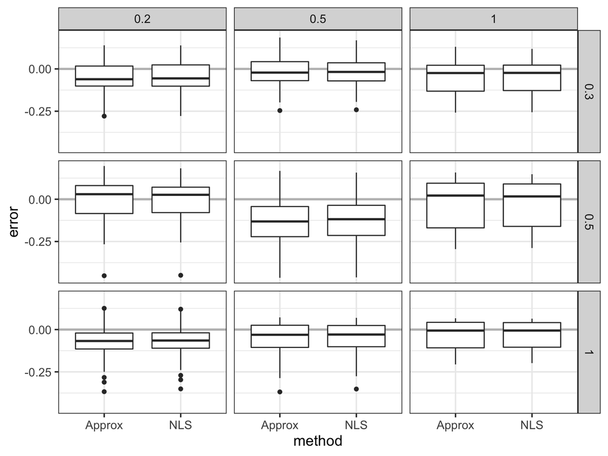

## Unmeasured (sparsely measured) dimensions?

Consider the simple viral dynamics model:

$$\begin{align}
\dot{T}&=\lambda-\beta T V-d_{T} T\\
\dot{I}&=\beta T V-d_{I} I \\
\dot{V}&=kI-c V
\end{align}$$

Take the B2 group as example. We have

- (almost) weekly measurements of $V$
- 3 measurements (at week 0, 4, 8) of $T$
- no measurements of $I$

Potential solutions:

1. Assume a “reasonable” trajectory for $I$ (e.g., let $I$ simply be some small fraction of $T$) and reduce the system to a 2-dim one, and then we can do NLS
2. Adopt a simulation-based approach (a Bayesian approach), which
   - requires writing down the “complete data likelihood”; and rigorously that involves converting the ODE system into a continuous-time Markov Chain (or at least an approximation of it)
   - iteratively proposes parameter values and event sequences (“complete data”) and then accepts/rejects the proposals according to a Metropolis-Hastings ratio
   - can technically deal with an unobserved dimension, **but** it won’t be computationally efficient (the latent space is very high-dimensional), and with this specific model there is an identifiability issue (due to the $kI$ and $d_I I$ terms)
   - can give the “real” parameter posterior and uncertainty quantification
3. An ABC-type approach, which
   - is “likelihood-free”, but requires carefull choice of the distance/discrepancy function between simulated data $y^*$ and observed data $y$; the good thing is, with dynamical systems, we can directly compare data points instead of making up summary statistics
   - enables model comparison by allowing for Bayes factor computation
   - also can technically deal with unobserved dimensions

## References

Adams et al. (2005). HIV dynamics: Modeling, data analysis, and optimal treatment protocols. *Journal of computational and applied mathematics*.

Wallace et al. (2012). Linear noise approximation is valid over limited times for any chemical systems that is sufficiently large. *IET systems biology*.

Toni et al. (2008). Approximate Bayesian computation scheme for parameter inference and model selection in dynamical systems." *Journal of the Royal Society Interface*.